# Vota Unicamp!

Relatório Final

Ana Flávia Polisel, Bruna Mendes Heyn, Eliane Ramos de Siqueira, Gustavo Cordeiro, Michely Wu Hsieh e Natalia Rodrigues da Silva

## 0.1 Introdução e objetivo

[output not shown]

```
## [1] ""
```

## 0.2 Tabela de Dados Original

Essa tabela apresenta todos os dados presentes no site dividos em sete categorias: Código do curso, nível do curso, nome do curso, total de votos, número de sim, número de não e número de abstenção.

|  | codigo | nivel | curso | total | sim | nao | abstencao |
| --- | --- | --- | --- | --- | --- | --- | --- |
| 1 | 1 | Graduacao | Matemática | 3 | 2 | 1 | 0 |
| 2 | 1 | Mestrado | Matemática | 1 | 0 | 1 | 0 |
| 3 | 10 | Graduacao | Engenharia Mecânica | 40 | 10 | 30 | 0 |
| 4 | 10 | Mestrado | Engenharia Mecânica | 4 | 2 | 2 | 0 |
| 5 | 100 | Graduacao | Ciências do Esporte | 2 | 0 | 2 | 0 |
| 6 | 101 | Graduacao | Engenharia de Manufatura | 3 | 0 | 3 | 0 |
| 7 | 102 | Graduacao | Engenharia de Produção | 3 | 0 | 3 | 0 |
| 8 | 105 | Graduacao | Gestão de Empresas | 1 | 0 | 1 | 0 |
| 9 | 107 | Graduacao | Nutrição | 1 | 0 | 1 | 0 |
| 10 | 108 | Graduacao | Engenharia Física | 2 | 1 | 1 | 0 |

[output cut: 72 more lines]

## 0.3 Análises

### 0.3.1 Análise da Graduação por Áreas

Na tabela abaixo, foi adicionada uma coluna com a àrea correspondente de cada curso, e duas colunas com as proporções de votos favoráveis e não favoráveis á greve, respectivamente.

|  | codigo | nivel | curso | total | sim | nao | abstencao | Area | Proporção de Sim | Proporção de Não |
| --- | --- | --- | --- | --- | --- | --- | --- | --- | --- | --- |
| 1 | 1 | Graduacao | Matemática | 3 | 2 | 1 | 0 | Exatas | 0.667 | 0.333 |
| 2 | 10 | Graduacao | Engenharia Mecânica | 40 | 10 | 30 | 0 | Exatas | 0.25 | 0.75 |
| 3 | 101 | Graduacao | Engenharia de Manufatura | 3 | 0 | 3 | 0 | Exatas | 0 | 1 |
| 4 | 102 | Graduacao | Engenharia de Produção | 3 | 0 | 3 | 0 | Exatas | 0 | 1 |
| 5 | 108 | Graduacao | Engenharia Física | 2 | 1 | 1 | 0 | Exatas | 0.5 | 0.5 |
| 6 | 11 | Graduacao | Engenharia Elétrica | 30 | 3 | 26 | 1 | Exatas | 0.1 | 0.867 |
| 7 | 12 | Graduacao | Engenharia Civil | 12 | 2 | 10 | 0 | Exatas | 0.167 | 0.833 |
| 8 | 13 | Graduacao | Engenharia de Alimentos | 4 | 0 | 4 | 0 | Exatas | 0 | 1 |
| 9 | 2 | Graduacao | Estatística | 30 | 5 | 24 | 1 | Exatas | 0.167 | 0.8 |
| 10 | 28 | Graduacao | Matemática Aplicada e Computacional | 2 | 0 | 2 | 0 | Exatas | 0 | 1 |

[output cut: 44 more lines]

### 0.3.2 Gráficos

Abaixo, organizamos os dados, já separados por área, em uma tabela e em um gráfico nos quais podemos ver a proporção de votos sim, não e abstençao em cada uma delas. A intensão é que, através disso, possamos avaliar se a área do curso de cada aluno que respondeu a pesquisa influencia, ou não, na sua opinião a respeito da greve.

|  | Exatas | Humanas | Biológicas | Artes | P. Especiais |
| --- | --- | --- | --- | --- | --- |
| Prop. Sim | 0.266 | 0.566 | 0.222 | 0.727 | 0 |
| Prop. Não | 0.696 | 0.434 | 0.733 | 0.091 | 1 |
| Prop. Abstenção | 0.266 | 0 | 0.044 | 0.182 | 0 |

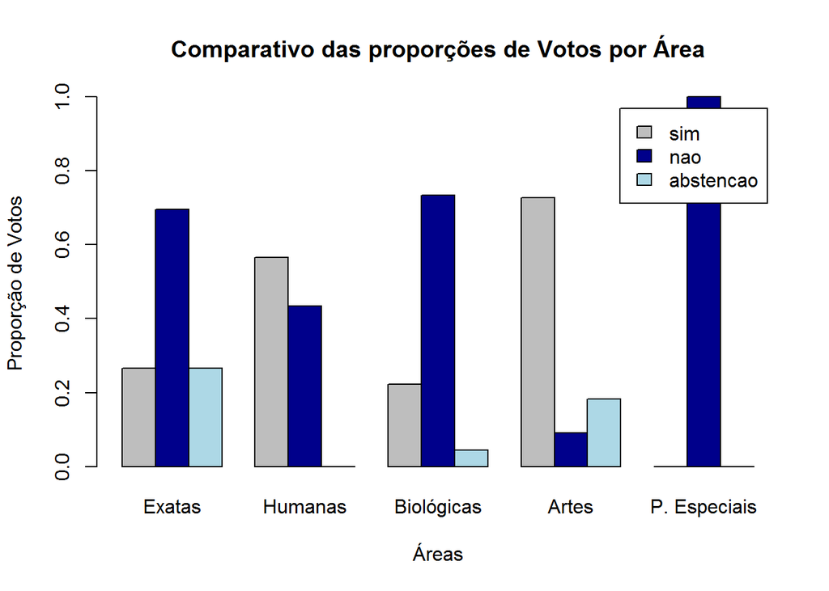

### 0.3.3 Análise da Graduação por Instituto

Na tabela abaixo organizamos os cursos de graduação de acordo com o isntituto ao qual cada um pertence. Utilizaremos esta tabela como base para gerar gráficos nos quais poderemos comparar a proporção de votos em cada um dos institutos.

|  | codigo | nivel | curso | total | sim | nao | abstencao | Instituto | Proporção de Sim | Proporção de Não |
| --- | --- | --- | --- | --- | --- | --- | --- | --- | --- | --- |
| 1 | 1 | Graduacao | Matemática | 3 | 2 | 1 | 0 | IMECC | 0.667 | 0.333 |
| 2 | 2 | Graduacao | Estatística | 30 | 5 | 24 | 1 | IMECC | 0.167 | 0.8 |
| 3 | 28 | Graduacao | Matemática Aplicada e Computacional | 2 | 0 | 2 | 0 | IMECC | 0 | 1 |
| 4 | 29 | Graduacao | Licenciatura em Matemática | 4 | 1 | 3 | 0 | IMECC | 0.25 | 0.75 |
| 5 | 10 | Graduacao | Engenharia Mecânica | 40 | 10 | 30 | 0 | FEM | 0.25 | 0.75 |
| 6 | 49 | Graduacao | Engenharia de Controle e Automação | 17 | 8 | 9 | 0 | FEM | 0.471 | 0.529 |
| 7 | 100 | Graduacao | Ciências do Esporte | 2 | 0 | 2 | 0 | FCA | 0 | 1 |
| 8 | 101 | Graduacao | Engenharia de Manufatura | 3 | 0 | 3 | 0 | FCA | 0 | 1 |
| 9 | 102 | Graduacao | Engenharia de Produção | 3 | 0 | 3 | 0 | FCA | 0 | 1 |
| 10 | 107 | Graduacao | Nutrição | 1 | 0 | 1 | 0 | FCA | 0 | 1 |

[output cut: 38 more lines]

No gráfico abaixo podemos ver a proporção de votos em cada um dos institutos. O objetivo deste gráfico é podermos observar, separadamente, quais dos institutos tem mais votos a favor ou contra o movimento de greve.

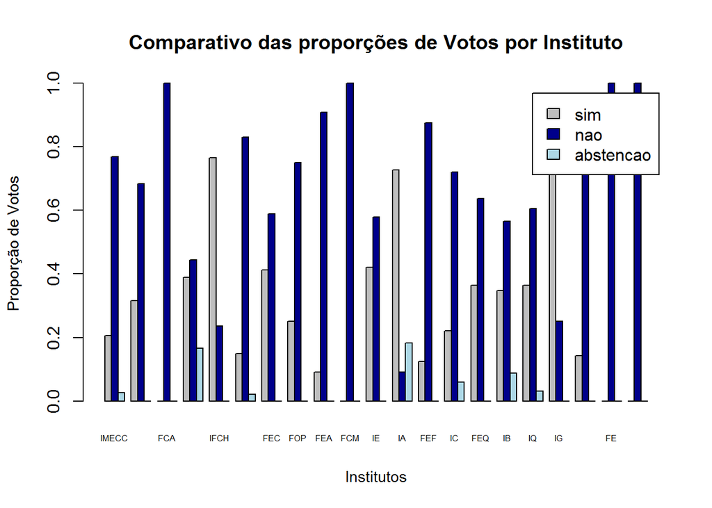

Podemos ver que, na grande maioria dos institutos, a proporção de votos contrários a greve é maior do que a proporção de alunos a favor.

### 0.3.4 Proporção Geral de Votos da Graduação

O gráfico abaixo mostra a proporção de votos “sim”, “não” e “abstenção” dos alunos da graduação.

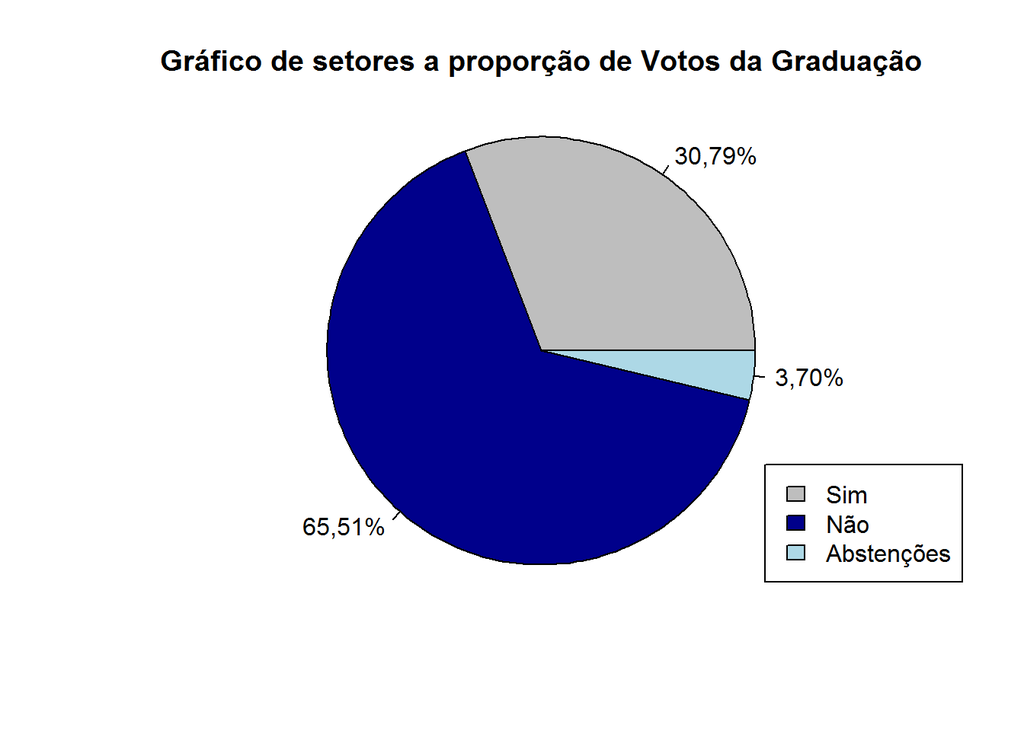

Ao analisarmos estes gráficos podemos concluir que, segundo a pesquisa, a maioria dos alunos dos cursos de graduação da Unicamp são contrários ao movimento da greve estudantil. O que revela uma contadição com a atual condição da universidade, que tem 18 dos seus institutos em greve.

### 0.3.5 Teste de Hipótese para proporção

Dado que, nos gráficos e tabelas anteriores, observamos que a proporção de votos “não” é maior que a proporção de votos “sim”, queremos testar se essa proporção amostral é suficiente para dizermos que o opinião populacional também é contrária a greve. Para isso vamos realizar um teste de hipóteses para essas proporções.

Para fazer esse tipo de teste definimos duas hipóteses $H_0$ e $H_1$, que são chamadas respectivamente de hipótese nula e hipótese alternativa. No nosso caso $H_0$: proporção de sim >ou= 50% e $H_1$: proporção de sim < 50%

```
##
##  1-sample proportions test with continuity correction
##
## data:  x, null probability 0.5
## X-squared = 53.368, df = 1, p-value = 1.383e-13
## alternative hypothesis: true p is less than 0.5
## 95 percent confidence interval:
##  0.0000000 0.3596143
## sample estimates:
##         p
## 0.3197115
```

### 0.3.6 Tamanho amostral por curso de Graduação

O tamanho amostral foi determinado através da fórmula para amostra aleatória simples sem reposição, sendo $p=\frac{1}{2}$ (pior caso):

$$n=\frac{N}{(4(N-1)D+1)}$$

sendo $D=B²/z²$.

Definimos $B=0.1$, ou seja, o erro será de no máximo 10% e $Z=1.96$, pois aproximamos nossa distribuição para uma normal padrão com 95% de significância, o que nos deu os tamanhos amostrais presentes na tabela abaixo.

|  | Código | Curso | Número de Matriculados | Total de Votos | Tamanho Amostral |
| --- | --- | --- | --- | --- | --- |
| 1 | 1 | Matemática | 67 | 3 | 40 |
| 2 | 10 | Engenharia Mecânica | 891 | 40 | 87 |
| 3 | 101 | Engenharia de Manufatura | 363 | 3 | 76 |
| 4 | 102 | Engenharia de Produção | 361 | 3 | 76 |
| 5 | 108 | Engenharia Física | 30 | 2 | 23 |
| 6 | 11 | Engenharia Elétrica | 426 | 30 | 79 |
| 7 | 12 | Engenharia Civil | 515 | 12 | 81 |
| 8 | 13 | Engenharia de Alimentos | 467 | 4 | 80 |
| 9 | 2 | Estatística | 312 | 30 | 74 |
| 10 | 28 | Matemática Aplicada e Computacional | 75 | 2 | 42 |

[output cut: 43 more lines]

Observando a tabela acima, podemos ver que em todos os cursos, o número de votos registrados nesta pesquisa não atinge o valor do tamanho amostral calculado,o que deixa claro que os dados são viesados e não representam a população de alunos regularmente matriculados nos curso de graduação da UNICAMP.

# 1 Separação por áreas na pós-graduação

Apesar da greve estudantil ser articulada pelos estudantes da graduação, achamos válido fazer uma análise dos estudantes da pós-graduação, separados em Mestrado e Doutorado para saber se a opinião destes é semelhante à dos alunos da graduação em suas respectivas áreas, levando em conta que o movimento estudantil tem ganhado força e, com isso, interfere também em suas vidas acadêmicas.

## 1.1 Análises para Mestrado

### 1.1.1 Análise do Mestrado por Área

### 1.1.2 Tabela de Dados para Mestrado

|  | codigo | nivel | curso | total | sim | nao | abstencao | Area |
| --- | --- | --- | --- | --- | --- | --- | --- | --- |
| 1 | 1 | Mestrado | Matemática | 1 | 0 | 1 | 0 | Exatas |
| 2 | 10 | Mestrado | Engenharia Mecânica | 4 | 2 | 2 | 0 | Exatas |
| 3 | 11 | Mestrado | Engenharia Elétrica | 2 | 1 | 1 | 0 | Exatas |
| 4 | 12 | Mestrado | Engenharia Civil | 1 | 0 | 1 | 0 | Exatas |
| 5 | 2 | Mestrado | Estatística | 1 | 0 | 1 | 0 | Exatas |
| 6 | 3 | Mestrado | Ciência da Computação | 4 | 0 | 4 | 0 | Exatas |
| 7 | 4 | Mestrado | Mat.Aplic.e Computacional | 1 | 0 | 1 | 0 | Exatas |
| 8 | 5 | Mestrado | Química | 1 | 0 | 1 | 0 | Exatas |
| 9 | 62 | Mestrado | Genética e Biologia Molecular | 1 | 0 | 1 | 0 | Biológicas |
| 10 | 83 | Mestrado | Mestr.Bioc. e Tec. de Produtos Bioativos | 1 | 0 | 1 | 0 | Biológicas |

[output cut: 1 more lines]

### 1.1.3 Gráfico das proporções por Área

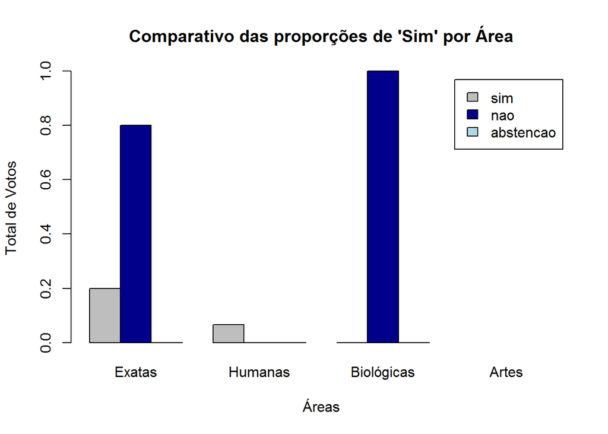

### 1.1.4 Proporção Geral de Votos do Mestrado

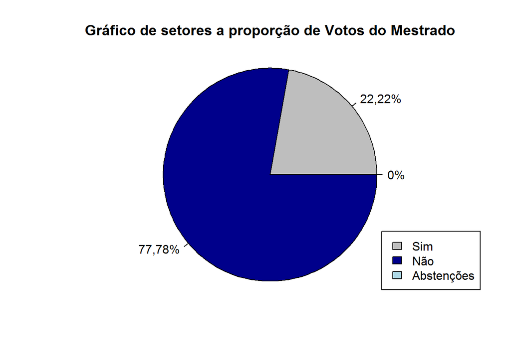

Como o tamanho da amostra de votos do mestrado é pequeno, não podemos ter respostas certeiras sobre a opinião destas pessoas, contudo os resultados tendem a serem similares com os alunos da graduação.

### 1.1.5 Teste de Hipótese

Assim como fizemos para a graduação, faremos um teste de hipóteses para a proporção de votos do mestrado utilizando as mesmas hipoteses e o mesmo ($\alpha$), ou seja: $H_0$: proporção de sim >ou= 50% e $H_1$: proporção de sim < 50% e ($\alpha$)=0.05

```
##
##  1-sample proportions test with continuity correction
##
## data:  y, null probability 0.5
## X-squared = 4.5, df = 1, p-value = 0.01695
## alternative hypothesis: true p is less than 0.5
## 95 percent confidence interval:
##  0.0000000 0.4425647
## sample estimates:
##         p
## 0.2222222
```

## 1.2 Análises para Doutorado

### 1.2.1 Tabela de Dados para Doutorado

|  | codigo | nivel | curso | total | sim | nao | abstencao | Area |
| --- | --- | --- | --- | --- | --- | --- | --- | --- |
| 1 | 51 | Doutorado | Matemática | 2 | 0 | 2 | 0 | Exatas |
| 2 | 53 | Doutorado | Ciência da Computação | 3 | 0 | 3 | 0 | Exatas |
| 3 | 54 | Doutorado | Física | 2 | 1 | 0 | 1 | Exatas |
| 4 | 55 | Doutorado | Química | 1 | 0 | 1 | 0 | Exatas |
| 5 | 61 | Doutorado | Engenharia Elétrica | 2 | 0 | 2 | 0 | Exatas |
| 6 | 79 | Doutorado | Matemática Aplicada | 2 | 1 | 1 | 0 | Exatas |
| 7 | 92 | Doutorado | Dout.na Área Int. Plan.Sist.Energéticos | 1 | 0 | 1 | 0 | Exatas |
| 8 | 98 | Doutorado | Ciências e Engª de Petróleo | 1 | 0 | 1 | 0 | Exatas |
| 9 | 11 | Doutorado | Genética e Biologia Molecular | 3 | 0 | 3 | 0 | Biológicas |
| 10 | 13 | Doutorado | Ecologia | 1 | 0 | 1 | 0 | Biológicas |

[output cut: 4 more lines]

### 1.2.2 Gráfico das proporções por Área

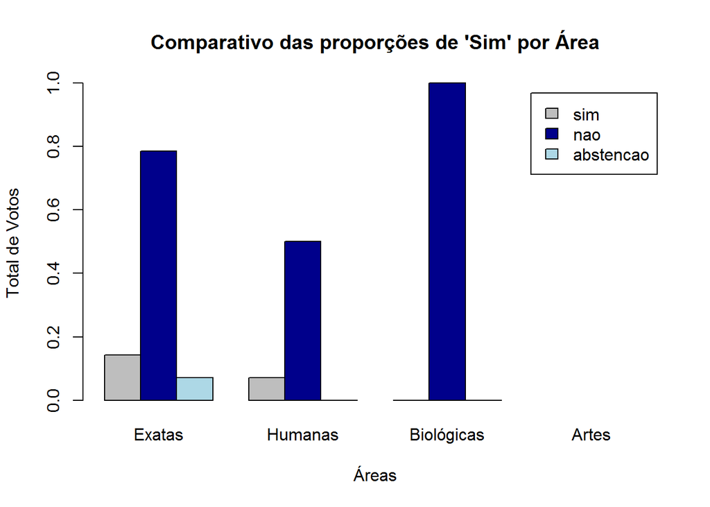

Os alunos de doutorado seguem o mesmo padrão dos de mestrado e graduação. Apesar dos poucos votos, os gráficos de exatas e biológicas acima indicam que os alunos destas áreas são contrários a greve.

### 1.2.3 Proporção Geral de Votos do Doutorado

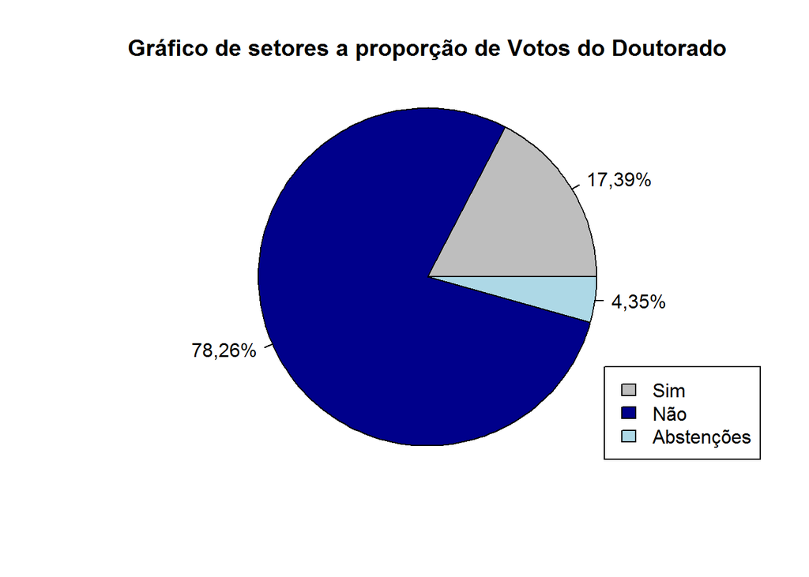

### 1.2.4 Teste de Hipótese

Assim como fizemos para a graduação e para o mestrado, faremos um teste de hipóteses para a proporção de votos do doutorado utilizando as mesmas hipoteses e o mesmo ($\alpha$), ou seja: $H_0$: proporção de sim >ou= 50% e $H_1$: proporção de sim < 50% e ($\alpha$)=0.05

```
##
##  1-sample proportions test with continuity correction
##
## data:  z, null probability 0.5
## X-squared = 7.6818, df = 1, p-value = 0.002789
## alternative hypothesis: true p is less than 0.5
## 95 percent confidence interval:
##  0.0000000 0.3742516
## sample estimates:
##         p
## 0.1818182
```

## 1.3 Gauge Plots

```r
tbl0 = subset(mytbl, nivel=='Graduacao')
tbl0$pnao = round(tbl0$nao/tbl0$total*100, 0)
gauge = gvisGauge(tbl0[, c('curso', 'pnao')], 'curso', 'nao',
                  options=list(min=0, max=100, greenFrom=0,
                                 greenTo=20, yellowFrom=40, yellowTo=60,
                                 redFrom=80, redTo=100, width=400, height=300))
plot(gauge)
```

[output not shown]

```
## starting httpd help server ...
```

```
##  done
```

## 1.4 Obtenção de Dados Geográficos

Esse mapa mostra a localização de cada um dos institutos da Unicamp mencionados no trabalho.

[interactive chart not shown]

## 1.5 Intervalos de Confiança

Abaixo colocamos uma tabela com os intervalos de confiaça para a proporção de votos não para cada curso. Um intervalo de confinança significa a cada 100 vezes que essa pesquisa for feita, em média em 95 delas a proporção de “nãos” estará dentro desse intervalo.

```r
p = with(mytbl, nao/(total))
mes = qnorm(.975)*sqrt(1/(4*mytbl$total))
ics = cbind(pmax(p-mes, 0), pmin(p+mes, 1))
colnames(ics) = c("lower", "upper")
mytbl$p = p
tabelaIC<- data.frame(mytbl$codigo,mytbl$nivel, mytbl$curso,mytbl$p)
tabelaic2 = cbind(tabelaIC, ics)
colnames(tabelaic2)=c("Código", "Nível", "Total","p","Limite Inferior","Limite Superior")
datatable(tabelaic2, options = list(pageLength = 10))
```

|  | Código | Nível | Total | p | Limite Inferior | Limite Superior |
| --- | --- | --- | --- | --- | --- | --- |
| 1 | 1 | Graduacao | Matemática | 0.333333333333333 | 0 | 0.899126200371419 |
| 2 | 1 | Mestrado | Matemática | 1 | 0.0200180077299732 | 1 |
| 3 | 10 | Graduacao | Engenharia Mecânica | 0.75 | 0.59505124192386 | 0.90494875807614 |
| 4 | 10 | Mestrado | Engenharia Mecânica | 0.5 | 0.0100090038649866 | 0.989990996135013 |
| 5 | 100 | Graduacao | Ciências do Esporte | 1 | 0.307048087825161 | 1 |
| 6 | 101 | Graduacao | Engenharia de Manufatura | 1 | 0.434207132961914 | 1 |
| 7 | 102 | Graduacao | Engenharia de Produção | 1 | 0.434207132961914 | 1 |
| 8 | 105 | Graduacao | Gestão de Empresas | 1 | 0.0200180077299732 | 1 |
| 9 | 107 | Graduacao | Nutrição | 1 | 0.0200180077299732 | 1 |
| 10 | 108 | Graduacao | Engenharia Física | 0.5 | 0 | 1 |

[output cut: 72 more lines]

## 1.6 Conclusão

Diante de todos os dados análisados,interpretação dos gráficos e o que vivenciamos durante todo período de greve em nossa universidade, acreditamos que, apesar do número de votos presentes no site “votaunicamp” ter sido baixo, podemos considerar que a amostra se aproxima da realidade. Notamos que os alunos de exatas e biológicas, em sua maioria, tendem a serem contrários a greve. Enquanto os alunos de humanas e artes são a favor, isso se deve ao fato desses cursos estarem diretamente ligados às questões sociais. A decisão a respeito da greve é feita através de assembléias, que são reuniões organizadas pelo centro acadêmico de cada instituto, os quais são formados, majoritariamente por alunos favoráveis ao movimento. Devido as atividades e cronogramas acadêmicos a serem cumpridos, muitos dos estudantes contrários a greve não abrem mão de seus afazeres para comparecerem a tais reuniões que acabam contando com um número reduzido de alunos que, em sua maioria, votam a favor. Vale ressaltar também que pelo motivo da pesquisa não ser anônima, pode causar possível receio dos alunos que são favoráveis a greve, pelo fato de precisar identificar o seu primeiro nome, seu curso e seu RG, fazendo que sejam expostos aos docentes que terão acesso a essa pesquisa.Portanto os dados podem ser tendenciosos. Até o momento mais da metade dos institutos da UNICAMP estão em greve o que revela um contraste com os resultados da pesquisa, e, além disso evidencia um fato que, por motivos como os relatados acima, tem sido fortemente questionado por docentes e estudantes: a não representatividade das assembléias. Sabemos que a posição de cada estudante mediante a greve é muito importante para chegar a uma conclusão mais justa. Com isso, a votação por assembleias e online são essenciais para obtermos um resultado certeiro.